# Predicting Customer Churn

Jorge Ferreira

Let’s start by reading in the dataset so we can investigate all customers’ attributes.

```r
churn <- read.csv('~/Desktop/Telco Customer Churn.csv')
head(churn)
```

```
##   customerID gender SeniorCitizen Partner Dependents tenure PhoneService
## 1 7590-VHVEG Female             0     Yes         No      1           No
## 2 5575-GNVDE   Male             0      No         No     34          Yes
## 3 3668-QPYBK   Male             0      No         No      2          Yes
## 4 7795-CFOCW   Male             0      No         No     45           No
## 5 9237-HQITU Female             0      No         No      2          Yes
## 6 9305-CDSKC Female             0      No         No      8          Yes
##      MultipleLines InternetService OnlineSecurity OnlineBackup
## 1 No phone service             DSL             No          Yes
## 2               No             DSL            Yes           No
## 3               No             DSL            Yes          Yes
## 4 No phone service             DSL            Yes           No
## 5               No     Fiber optic             No           No
## 6              Yes     Fiber optic             No           No
##   DeviceProtection TechSupport StreamingTV StreamingMovies       Contract
```

[output cut: 20 more lines]

```r
dim(churn)
```

```
## [1] 7043   21
```

We have access to information on 7043 clients, with 21 attributes.

The dataset provides us the features below:

- customerID
- gender (female, male)
- SeniorCitizen: whether the customer is a senior citizen or not (1, 0)
- Partner: whether the customer has a partner or not (Yes, No)
- Dependents: whether the customer has dependents or not (Yes, No)
- Tenure: number of months the customer has stayed with the company
- PhoneService: whether the customer has a phone service or not (Yes, No)
- MultipleLines: whether the customer has multiple lines or not (Yes, No, No phone service)
- InternetService: customers internet service provider (DSL, Fiber optic, No)
- OnlineSecurity: whether the customer has online security or not (Yes, No, No internet service)
- OnlineBackup: whether the customer has online backup or not (Yes, No, No internet service)
- DeviceProtection: whether the customer has device protection or not (Yes, No, No internet service)
- TechSupport: whether the customer has tech support or not (Yes, No, No internet service)
- StreamingTV: whether the customer has streaming TV or not (Yes, No, No internet service)
- StreamingMovies: whether the customer has streaming movies or not (Yes, No, No internet service)
- Contract: the contract term of the customer (Month-to-month, One year, Two year)
- PaperlessBilling: whether the customer has paperless billing or not (Yes, No)
- PaymentMethod: the customers payment method - Electronic check, Mailed check, Bank transfer (automatic), Credit card (automatic)
- MonthlyCharges: the amount charged to the customer monthly (numeric)
- TotalCharges: the total amount charged to the customer (numeric)
- Churn: whether the customer churned or not (Yes or No) - our target variable!

```r
sapply(churn, function(x) sum(is.na(x)))
```

```
##       customerID           gender    SeniorCitizen          Partner
##                0                0                0                0
##       Dependents           tenure     PhoneService    MultipleLines
##                0                0                0                0
##  InternetService   OnlineSecurity     OnlineBackup DeviceProtection
##                0                0                0                0
##      TechSupport      StreamingTV  StreamingMovies         Contract
##                0                0                0                0
## PaperlessBilling    PaymentMethod   MonthlyCharges     TotalCharges
##                0                0                0               11
##            Churn
##                0
```

The dataset has 11 missing values, all of them under TotalCharges. An error might have occurred in the collection process, which prevented us from getting them correctly. But we have MonthlyCharges, which might be enough for the purpose of this exercise. In fact, if these two variables are highly correlated we can only use one of them to avoid multicollinearity.

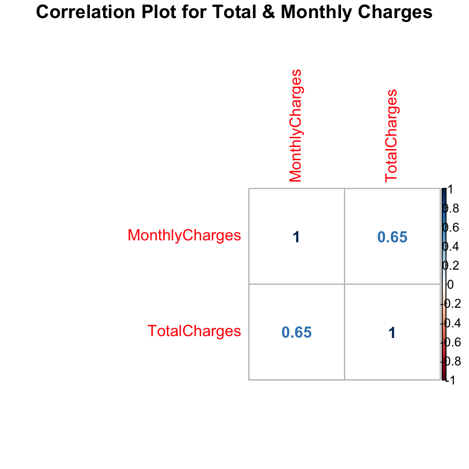

```r
library(corrplot)
complete <- churn[complete.cases(churn), ]
charges <- complete[,19:20]
corr.matrix <- cor(charges)
corrplot(corr.matrix, main="\nCorrelation Plot for Total & Monthly Charges", method="number")
```

As Monthly and Total Charges are correlated and we lack data for Total Charges, instead of getting rid of the rows with missing values, I will leave Total Charges out of the equation.

Regarding the tenure variable, it ranges from 0 to 72months. So, we can group them into five tenure groups:

```r
group_tenure <- function(tenure){
  if (tenure >= 0 & tenure <= 12){
    return('0-12 Month')
  }else if(tenure > 12 & tenure <= 24){
    return('12-24 Month')
  }else if (tenure > 24 & tenure <= 48){
    return('24-48 Month')
  }else if (tenure > 48 & tenure <=60){
    return('48-60 Month')
  }else if (tenure > 60){
    return('> 60 Month')
  }
}
churn$tenure_group <- sapply(churn$tenure,group_tenure)
churn$tenure_group <- as.factor(churn$tenure_group)
```

SeniorCitizen is a binary feature. Let’s change it in order to follow the same format as the remaining variables.

```r
churn$SeniorCitizen <- as.factor(ifelse(churn$SeniorCitizen==1,"Yes","No"))
```

Interestingly, there are a few attributes which should also have a “Yes/No” output but have different ways of providing the negative answer. Therefore, we need to change “No internet service”" to “No”" for six columns: “OnlineSecurity”“,”OnlineBackup“,”DeviceProtection“,”TechSupport“,”StreamingTV“,”StreamingMovies“.

```r
library(plyr)
for(i in 1:ncol(churn[,10:15])) {
  churn[,10:15][,i] <- as.factor(mapvalues
                                        (churn[,10:15][,i], from =c("No internet service"),to=c("No")))
}
```

This situation happens for for MultipleLines too, so let’s take the same approach.

```r
churn$MultipleLines <- as.factor(mapvalues(churn$MultipleLines,
                                           from=c("No phone service"),
                                           to=c("No")))
```

Before moving on to some exploratory analysis, we can ditch unnecessary variables which will add nothing to our predicting models.

```r
library(dplyr)
churn <- churn %>% select(-customerID, -tenure, -TotalCharges)
```

Below we can see how our categorical variables behave depending on churn outcomes.

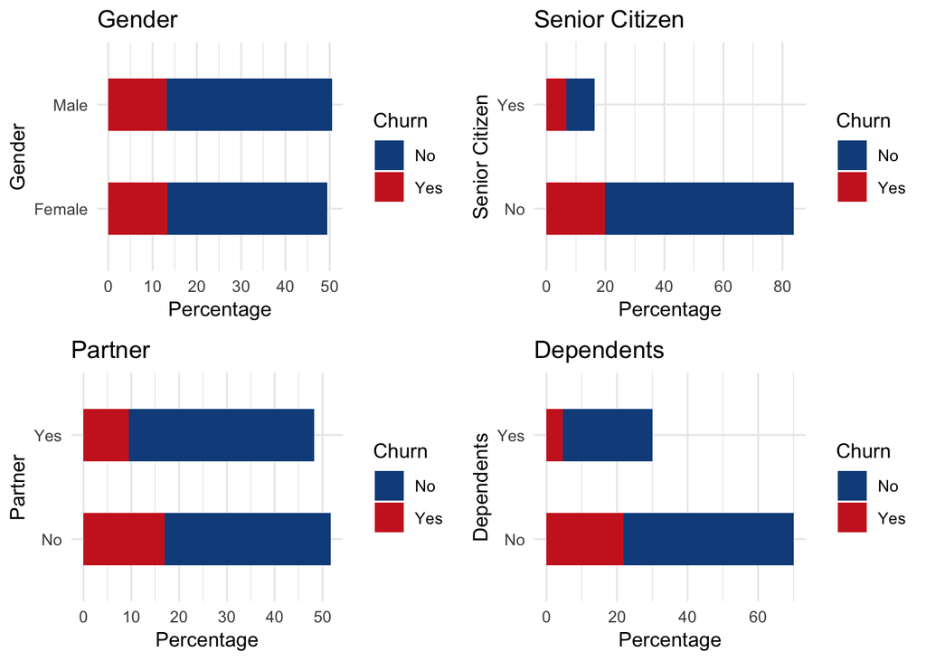

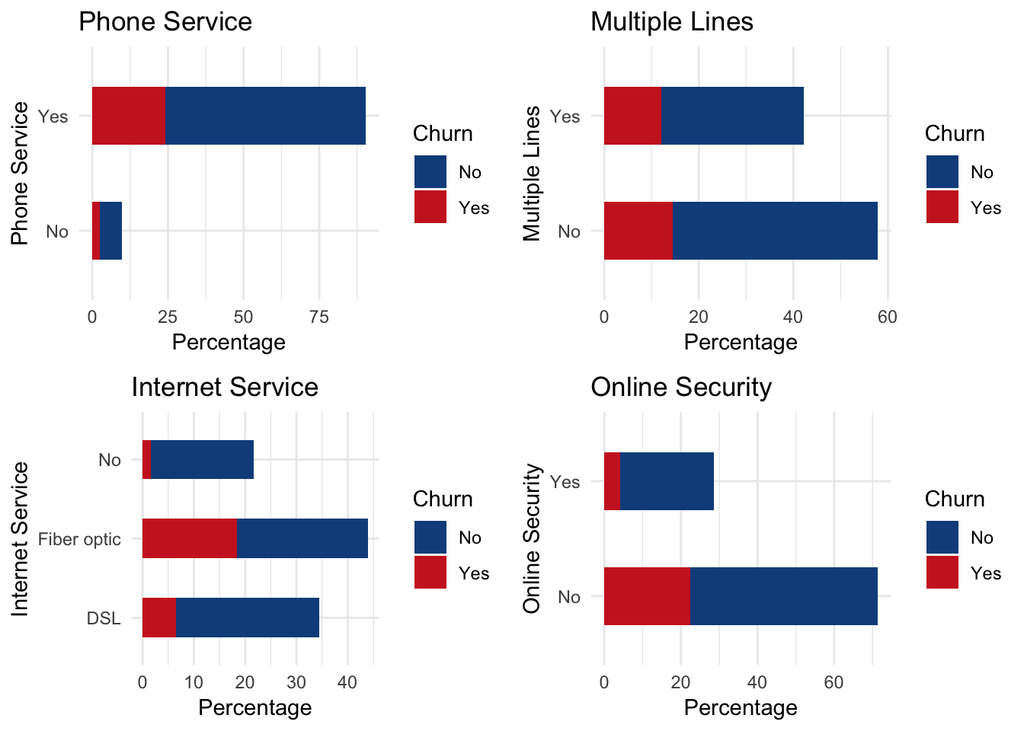

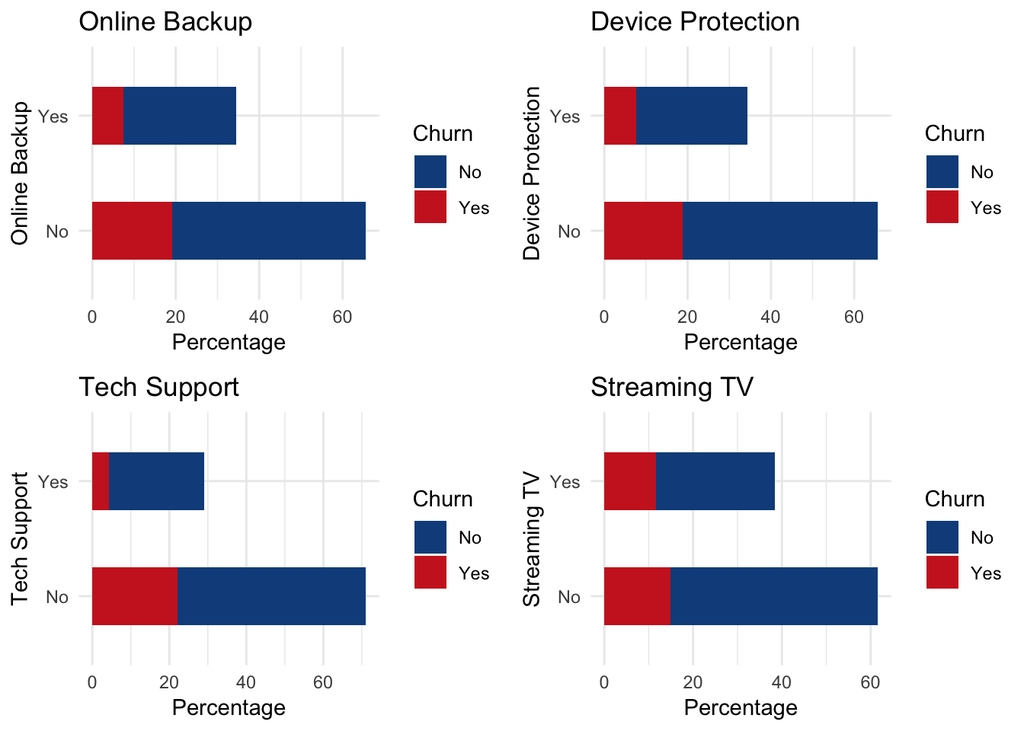

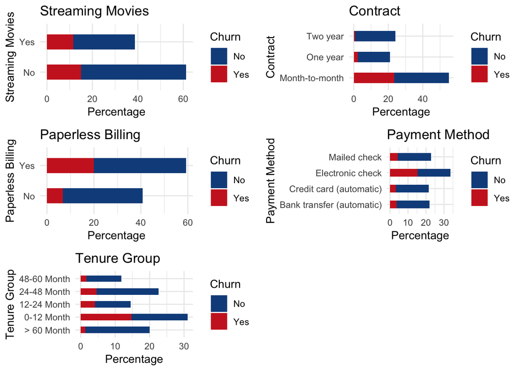

From the graphs above, we can easily see that, for example, gender doesn’t add much value to our prediction. Conversely, Month-to-Month contracts tend to churn more often than one or two year. Also, paperless billing customers are more likely to cancel their subscriptions. How do MonthlyCharges relate to churn?

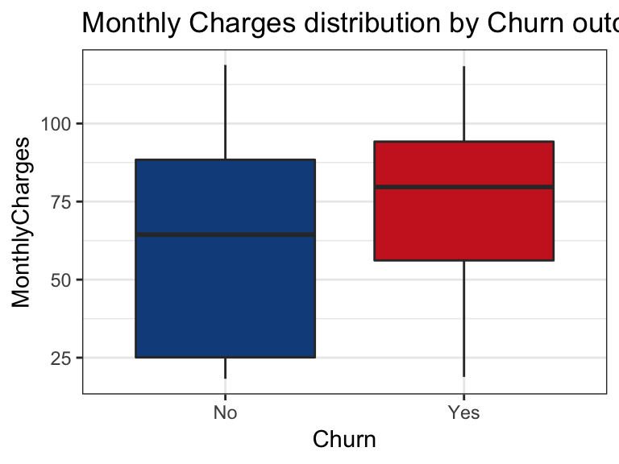

It seems we face a few churn risks for clients who have higher MonthlyCharges.

But let’s further analyse churn prediction using Logistic Regression.

```r
library(caret)
intrain<- createDataPartition(churn$Churn,p=0.7,list=FALSE)
set.seed(2019)
training<- churn[intrain,]
testing<- churn[-intrain,]
LogModel <- glm(Churn ~ .,family=binomial(link="logit"),data=training)
print(summary(LogModel))
```

```
##
## Call:
## glm(formula = Churn ~ ., family = binomial(link = "logit"), data = training)
##
## Deviance Residuals:
##     Min       1Q   Median       3Q      Max
## -1.9857  -0.6827  -0.2928   0.6859   3.1216
##
## Coefficients:
##                                      Estimate Std. Error z value Pr(>|z|)
## (Intercept)                          -0.99659    0.98632  -1.010 0.312298
## genderMale                           -0.04015    0.07749  -0.518 0.604365
## SeniorCitizenYes                      0.26708    0.09998   2.671 0.007558
## PartnerYes                           -0.03314    0.09177  -0.361 0.717996
## DependentsYes                        -0.08449    0.10633  -0.795 0.426836
## PhoneServiceYes                       0.19698    0.78252   0.252 0.801250
## MultipleLinesYes                      0.47184    0.21222   2.223 0.026190
## InternetServiceFiber optic            1.90776    0.96143   1.984 0.047222
## InternetServiceNo                    -1.74627    0.96994  -1.800 0.071799
## OnlineSecurityYes                    -0.13231    0.21406  -0.618 0.536516
## OnlineBackupYes                       0.05669    0.21235   0.267 0.789508
## DeviceProtectionYes                   0.16674    0.21220   0.786 0.432000
## TechSupportYes                       -0.06662    0.21750  -0.306 0.759377
## StreamingTVYes                        0.61802    0.39388   1.569 0.116631
## StreamingMoviesYes                    0.70870    0.39431   1.797 0.072283
## ContractOne year                     -0.76509    0.12783  -5.985 2.16e-09
## ContractTwo year                     -1.72042    0.21964  -7.833 4.77e-15
## PaperlessBillingYes                   0.31241    0.08940   3.495 0.000475
## PaymentMethodCredit card (automatic) -0.03450    0.13535  -0.255 0.798793
## PaymentMethodElectronic check         0.27402    0.11298   2.425 0.015293
## PaymentMethodMailed check            -0.04294    0.13549  -0.317 0.751291
## MonthlyCharges                       -0.03919    0.03821  -1.026 0.305110
## tenure_group0-12 Month                1.81837    0.20358   8.932  < 2e-16
## tenure_group12-24 Month               1.01517    0.19952   5.088 3.62e-07
## tenure_group24-48 Month               0.53022    0.18381   2.885 0.003918
## tenure_group48-60 Month               0.30053    0.19940   1.507 0.131764
##
## (Intercept)
## genderMale
## SeniorCitizenYes                     **
```

[output cut: 18 more lines]

```
## MonthlyCharges
## tenure_group0-12 Month               ***
## tenure_group12-24 Month              ***
## tenure_group24-48 Month              **
## tenure_group48-60 Month
## ---
## Signif. codes:  0 '***' 0.001 '**' 0.01 '*' 0.05 '.' 0.1 ' ' 1
##
## (Dispersion parameter for binomial family taken to be 1)
##
##     Null deviance: 5707.1  on 4930  degrees of freedom
## Residual deviance: 4107.7  on 4905  degrees of freedom
## AIC: 4159.7
##
## Number of Fisher Scoring iterations: 6
```

According to the Logistic Regression summary above, the top three most-relevant features include Contract, tenure_group and PaperlessBilling.

```r
anova(LogModel, test="Chisq")
```

```
## Analysis of Deviance Table
##
## Model: binomial, link: logit
##
## Response: Churn
##
## Terms added sequentially (first to last)
##
##
##                  Df Deviance Resid. Df Resid. Dev  Pr(>Chi)
## NULL                              4930     5707.1
## gender            1     0.25      4929     5706.8 0.6140666
## SeniorCitizen     1   113.28      4928     5593.5 < 2.2e-16 ***
## Partner           1   111.40      4927     5482.1 < 2.2e-16 ***
## Dependents        1    30.76      4926     5451.4 2.921e-08 ***
## PhoneService      1     0.08      4925     5451.3 0.7775022
## MultipleLines     1    10.10      4924     5441.2 0.0014788 **
## InternetService   2   477.62      4922     4963.6 < 2.2e-16 ***
## OnlineSecurity    1   160.22      4921     4803.4 < 2.2e-16 ***
## OnlineBackup      1    68.06      4920     4735.3 < 2.2e-16 ***
## DeviceProtection  1    42.20      4919     4693.1 8.245e-11 ***
## TechSupport       1    70.42      4918     4622.7 < 2.2e-16 ***
## StreamingTV       1     0.35      4917     4622.3 0.5552851
## StreamingMovies   1     0.99      4916     4621.4 0.3207921
## Contract          2   312.81      4914     4308.5 < 2.2e-16 ***
## PaperlessBilling  1    12.70      4913     4295.8 0.0003647 ***
## PaymentMethod     3    26.94      4910     4268.9 6.057e-06 ***
## MonthlyCharges    1     0.93      4909     4268.0 0.3348119
## tenure_group      4   160.29      4905     4107.7 < 2.2e-16 ***
## ---
## Signif. codes:  0 '***' 0.001 '**' 0.01 '*' 0.05 '.' 0.1 ' ' 1
```

Analyzing the deviance table we can see the drop in deviance when adding each variable one at a time. Adding InternetService, Contract, OnlineSecurity and tenure_group significantly reduces the residual deviance. Assessing the predictive ability of our model…

```r
testing$Churn <- as.character(testing$Churn)
testing$Churn[testing$Churn=="No"] <- "0"
testing$Churn[testing$Churn=="Yes"] <- "1"
fitted.results <- predict(LogModel,newdata=testing,type='response')
fitted.results <- ifelse(fitted.results > 0.5,1,0)
misClasificError <- mean(fitted.results != testing$Churn)
print(paste('Logistic Regression Accuracy',1-misClasificError))
```

```
## [1] "Logistic Regression Accuracy 0.803030303030303"
```

Although accuracy is good, I believe we can do as good as this but playing with less predictors. I will use the stepwise method to reduce the number of variables at stake.

```r
LogModel2 <- step(LogModel)
```

```
## Start:  AIC=4159.67
## Churn ~ gender + SeniorCitizen + Partner + Dependents + PhoneService +
##     MultipleLines + InternetService + OnlineSecurity + OnlineBackup +
##     DeviceProtection + TechSupport + StreamingTV + StreamingMovies +
##     Contract + PaperlessBilling + PaymentMethod + MonthlyCharges +
##     tenure_group
##
##                    Df Deviance    AIC
## - PhoneService      1   4107.7 4157.7
## - OnlineBackup      1   4107.7 4157.7
## - TechSupport       1   4107.8 4157.8
## - Partner           1   4107.8 4157.8
## - gender            1   4107.9 4157.9
## - OnlineSecurity    1   4108.1 4158.1
## - DeviceProtection  1   4108.3 4158.3
## - Dependents        1   4108.3 4158.3
## - MonthlyCharges    1   4108.7 4158.7
## <none>                  4107.7 4159.7
## - InternetService   2   4111.9 4159.9
## - StreamingTV       1   4110.1 4160.1
## - StreamingMovies   1   4110.9 4160.9
## - MultipleLines     1   4112.6 4162.6
## - SeniorCitizen     1   4114.8 4164.8
## - PaymentMethod     3   4120.5 4166.5
## - PaperlessBilling  1   4119.9 4169.9
## - Contract          2   4194.4 4242.4
## - tenure_group      4   4268.0 4312.0
##
## Step:  AIC=4157.73
## Churn ~ gender + SeniorCitizen + Partner + Dependents + MultipleLines +
##     InternetService + OnlineSecurity + OnlineBackup + DeviceProtection +
##     TechSupport + StreamingTV + StreamingMovies + Contract +
##     PaperlessBilling + PaymentMethod + MonthlyCharges + tenure_group
##
##                    Df Deviance    AIC
## - OnlineBackup      1   4107.7 4155.7
## - Partner           1   4107.9 4155.9
## - gender            1   4108.0 4156.0
## - Dependents        1   4108.4 4156.4
## - TechSupport       1   4108.8 4156.8
```

[output cut: 131 more lines]

```
##     PaymentMethod + MonthlyCharges + tenure_group
##
##                    Df Deviance    AIC
## <none>                  4111.9 4149.9
## - OnlineSecurity    1   4115.1 4151.1
## - SeniorCitizen     1   4120.7 4156.7
## - PaymentMethod     3   4125.6 4157.6
## - PaperlessBilling  1   4124.3 4160.3
## - MultipleLines     1   4129.3 4165.3
## - StreamingTV       1   4133.5 4169.5
## - MonthlyCharges    1   4136.3 4172.3
## - StreamingMovies   1   4143.1 4179.1
## - InternetService   2   4192.2 4226.2
## - Contract          2   4204.9 4238.9
## - tenure_group      4   4292.2 4322.2
```

```r
print(summary(LogModel2))
```

```
##
## Call:
## glm(formula = Churn ~ SeniorCitizen + MultipleLines + InternetService +
##     OnlineSecurity + StreamingTV + StreamingMovies + Contract +
##     PaperlessBilling + PaymentMethod + MonthlyCharges + tenure_group,
##     family = binomial(link = "logit"), data = training)
##
## Deviance Residuals:
##     Min       1Q   Median       3Q      Max
## -2.0058  -0.6806  -0.2923   0.6866   3.1200
##
## Coefficients:
##                                       Estimate Std. Error z value Pr(>|z|)
## (Intercept)                          -1.292519   0.349402  -3.699 0.000216
## SeniorCitizenYes                      0.290105   0.097780   2.967 0.003008
## MultipleLinesYes                      0.422040   0.101836   4.144 3.41e-05
## InternetServiceFiber optic            1.687526   0.211182   7.991 1.34e-15
## InternetServiceNo                    -1.498856   0.201055  -7.455 8.99e-14
## OnlineSecurityYes                    -0.186529   0.106079  -1.758 0.078680
## StreamingTVYes                        0.525684   0.113596   4.628 3.70e-06
## StreamingMoviesYes                    0.624623   0.112759   5.539 3.03e-08
## ContractOne year                     -0.774517   0.127155  -6.091 1.12e-09
## ContractTwo year                     -1.749369   0.216986  -8.062 7.50e-16
## PaperlessBillingYes                   0.313296   0.089238   3.511 0.000447
## PaymentMethodCredit card (automatic) -0.033058   0.135158  -0.245 0.806773
## PaymentMethodElectronic check         0.281677   0.112766   2.498 0.012493
## PaymentMethodMailed check            -0.044116   0.135223  -0.326 0.744239
## MonthlyCharges                       -0.029536   0.005988  -4.933 8.11e-07
## tenure_group0-12 Month                1.817088   0.195198   9.309  < 2e-16
## tenure_group12-24 Month               1.007002   0.194457   5.179 2.24e-07
## tenure_group24-48 Month               0.525052   0.181220   2.897 0.003764
## tenure_group48-60 Month               0.296959   0.198692   1.495 0.135025
##
## (Intercept)                          ***
## SeniorCitizenYes                     **
## MultipleLinesYes                     ***
## InternetServiceFiber optic           ***
## InternetServiceNo                    ***
## OnlineSecurityYes                    .
## StreamingTVYes                       ***
## StreamingMoviesYes                   ***
## ContractOne year                     ***
## ContractTwo year                     ***
## PaperlessBillingYes                  ***
## PaymentMethodCredit card (automatic)
## PaymentMethodElectronic check        *
## PaymentMethodMailed check
## MonthlyCharges                       ***
## tenure_group0-12 Month               ***
## tenure_group12-24 Month              ***
## tenure_group24-48 Month              **
## tenure_group48-60 Month
## ---
## Signif. codes:  0 '***' 0.001 '**' 0.01 '*' 0.05 '.' 0.1 ' ' 1
##
## (Dispersion parameter for binomial family taken to be 1)
##
##     Null deviance: 5707.1  on 4930  degrees of freedom
## Residual deviance: 4111.9  on 4912  degrees of freedom
## AIC: 4149.9
##
## Number of Fisher Scoring iterations: 6
```

```r
anova(LogModel2, test="Chisq")
```

```
## Analysis of Deviance Table
##
## Model: binomial, link: logit
##
## Response: Churn
##
## Terms added sequentially (first to last)
##
##
##                  Df Deviance Resid. Df Resid. Dev  Pr(>Chi)
## NULL                              4930     5707.1
## SeniorCitizen     1   113.37      4929     5593.7 < 2.2e-16 ***
## MultipleLines     1     3.66      4928     5590.0 0.0556351 .
## InternetService   2   502.28      4926     5087.8 < 2.2e-16 ***
## OnlineSecurity    1   200.67      4925     4887.1 < 2.2e-16 ***
## StreamingTV       1    12.56      4924     4874.5 0.0003940 ***
## StreamingMovies   1     2.71      4923     4871.8 0.0994258 .
## Contract          2   497.22      4921     4374.6 < 2.2e-16 ***
## PaperlessBilling  1    13.25      4920     4361.4 0.0002731 ***
## PaymentMethod     3    34.32      4917     4327.0 1.693e-07 ***
## MonthlyCharges    1    34.88      4916     4292.2 3.515e-09 ***
## tenure_group      4   180.21      4912     4111.9 < 2.2e-16 ***
## ---
## Signif. codes:  0 '***' 0.001 '**' 0.01 '*' 0.05 '.' 0.1 ' ' 1
```

```r
fitted.results2 <- predict(LogModel2,newdata=testing,type='response')
fitted.results2 <- ifelse(fitted.results2 > 0.5,1,0)
misClasificError2 <- mean(fitted.results2 != testing$Churn)
print(paste('Logistic Regression Accuracy',1-misClasificError2))
```

```
## [1] "Logistic Regression Accuracy 0.803503787878788"
```

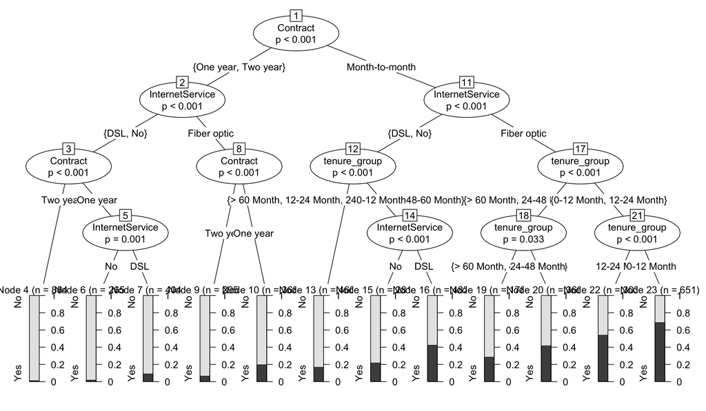

```r
library(party)
tree <- ctree(Churn~Contract+tenure_group+InternetService, training)
plot(tree)
```

- Out of three variables, Contract is the most important to predict customer churn;
- If a customer in a one-year or two-year contract, he/she is less likely to churn;
- If a customer is in a month-to-month contract, with Fibre Optic Internet Service and in the tenure group of 0???12 month, then this customer is more likely to churn.

```r
pred_tree <- predict(tree, testing)
print("Confusion Matrix for Decision Tree"); table(Predicted = pred_tree, Actual = testing$Churn)
```

```
## [1] "Confusion Matrix for Decision Tree"
```

```
##          Actual
## Predicted    0    1
##       No  1410  315
##       Yes  142  245
```

```r
p1 <- predict(tree, training)
tab1 <- table(Predicted = p1, Actual = training$Churn)
tab2 <- table(Predicted = pred_tree, Actual = testing$Churn)
print(paste('Decision Tree Accuracy',sum(diag(tab2))/sum(tab2)))
```

```
## [1] "Decision Tree Accuracy 0.783617424242424"
```

Accuracy slightly dropped when compared to Logistic Regression. But we were using only three predictors. Let’s see how better we can do by using Random Forest.

```r
library(randomForest)
rfModel <- randomForest(Churn ~., data = training)
print(rfModel)
```

```
##
## Call:
##  randomForest(formula = Churn ~ ., data = training)
##                Type of random forest: classification
##                      Number of trees: 500
## No. of variables tried at each split: 4
##
##         OOB estimate of  error rate: 21.13%
## Confusion matrix:
##       No Yes class.error
## No  3239 383   0.1057427
## Yes  659 650   0.5034377
```

The error rate seems to be higher when predicting “Yes”. We can also see it in the confusion matrix below:

```r
pred_rf <- predict(rfModel, testing)
testing$Churn2 <- as.factor(ifelse(testing$Churn=="1","Yes","No"))
caret::confusionMatrix(pred_rf, testing$Churn2)
```

```
## Confusion Matrix and Statistics
##
##           Reference
## Prediction   No  Yes
##        No  1396  278
##        Yes  156  282
##
##                Accuracy : 0.7945
##                  95% CI : (0.7766, 0.8116)
##     No Information Rate : 0.7348
##     P-Value [Acc > NIR] : 1.072e-10
##
##                   Kappa : 0.4332
##  Mcnemar's Test P-Value : 6.315e-09
##
##             Sensitivity : 0.8995
##             Specificity : 0.5036
##          Pos Pred Value : 0.8339
##          Neg Pred Value : 0.6438
##              Prevalence : 0.7348
##          Detection Rate : 0.6610
##    Detection Prevalence : 0.7926
##       Balanced Accuracy : 0.7015
##
##        'Positive' Class : No
##
```

We can use the following plot to determine the number of trees.

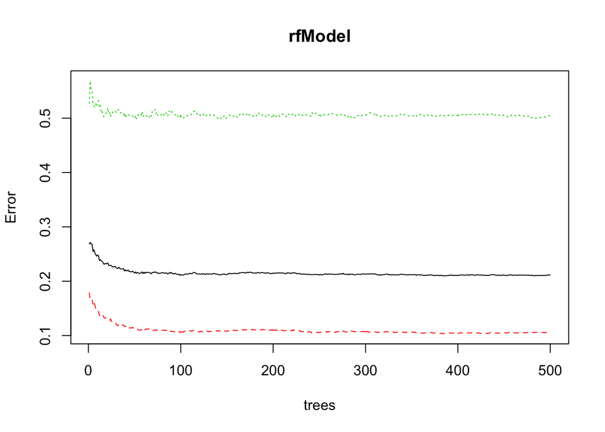

```r
plot(rfModel)
```

As the number of trees increases, the error rate decreases, and then becomes almost constant. We are not able to decrease the error rate after about 100 to 200 trees. Now let’s tune our model…

```
## mtry = 4  OOB error = 21.11%
## Searching left ...
## mtry = 8     OOB error = 21.88%
## -0.03650336 0.05
## Searching right ...
## mtry = 2     OOB error = 20.4%
## 0.03362152 0.05
```

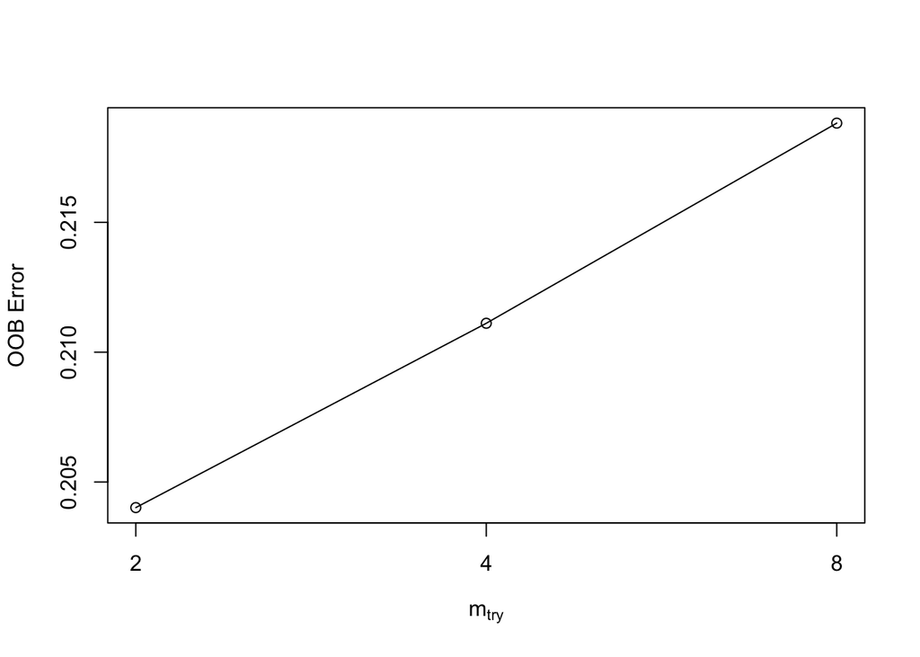

```r
t <- tuneRF(training[, -18], training[, 18], stepFactor = 0.5, plot = TRUE, ntreeTry = 200, trace = TRUE, improve = 0.05)
```

In order to increase our accuracy, the graphs suggest we need to use ntrees = 200 and 2 predictors for splitting at each node (mtry)

```r
rfModel_new <- randomForest(Churn ~., data = training, ntree = 200, mtry = 2, importance = TRUE, proximity = TRUE)
print(rfModel_new)
```

```
##
## Call:
##  randomForest(formula = Churn ~ ., data = training, ntree = 200,      mtry = 2, importance = TRUE, proximity = TRUE)
##                Type of random forest: classification
##                      Number of trees: 200
## No. of variables tried at each split: 2
##
##         OOB estimate of  error rate: 20.52%
## Confusion matrix:
##       No Yes class.error
## No  3300 322  0.08890116
## Yes  690 619  0.52711994
```

```r
pred_rf_new <- predict(rfModel_new, testing)
caret::confusionMatrix(pred_rf_new, testing$Churn2)
```

```
## Confusion Matrix and Statistics
##
##           Reference
## Prediction   No  Yes
##        No  1425  300
##        Yes  127  260
##
##                Accuracy : 0.7978
##                  95% CI : (0.78, 0.8148)
##     No Information Rate : 0.7348
##     P-Value [Acc > NIR] : 9.309e-12
##
##                   Kappa : 0.4244
##  Mcnemar's Test P-Value : < 2.2e-16
##
##             Sensitivity : 0.9182
##             Specificity : 0.4643
##          Pos Pred Value : 0.8261
##          Neg Pred Value : 0.6718
##              Prevalence : 0.7348
##          Detection Rate : 0.6747
##    Detection Prevalence : 0.8168
##       Balanced Accuracy : 0.6912
##
##        'Positive' Class : No
##
```

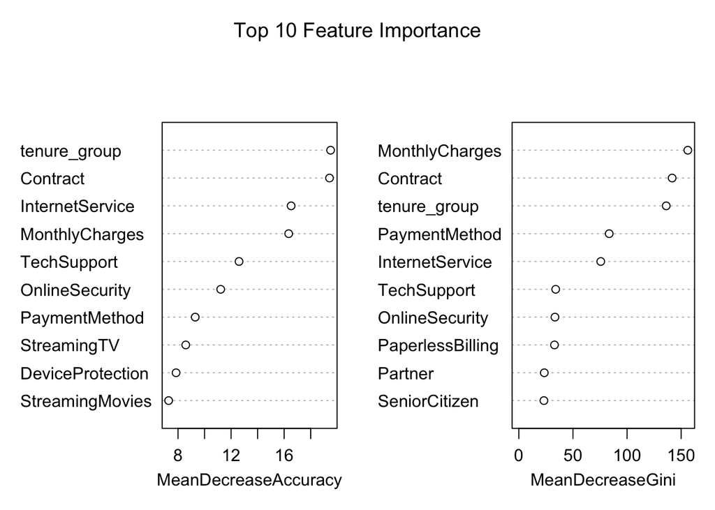

```r
varImpPlot(rfModel_new, sort=T, n.var = 10, main = 'Top 10 Feature Importance')
```

So, we can see that we can use Logistic Regression, Decision Trees and Random Forest for customer churn analysis for this particular dataset equally fine. From the three methods, we can conclude that tenure_group, Contract, PaperlessBilling, MonthlyCharges and InternetService appear to play a major role in customer churn.